# Peer pressure: Are the fitness benefits of animal personality traits affected by conspecific density?

Ho et al. (2023)

Aug 25,2023

These analyses are adapted from the [code that Matthew Whalen wrote in May 2022](https://github.com/mwhalen18/krsp-personality). I tweaked the code as needed as we finalized the models and analyses.

# Data cleaning

`scripts/r/data-cleaning.R`

We read in raw personality data from the master file (`data/personality-master-updated.csv`) and filtered for juveniles. We also ran filters to exclude:

- Records that indicated that they should be excluded
- Personality data scored by SWK due to GC experiment
- Any re-trials (i.e., only included the first trial for each individual)
- Squirrels from any grid other than **JO, KL, and SU**

The model in `scripts/r/model-training.R` was used to predict and impute as many missing parturition dates as possible.

```r
personality <- read.csv("data/personality-mrw-imputed.csv")

glimpse(personality)
```

```
## Rows: 257
## Columns: 38
## $ squirrel_id      <int> 6499, 7087, 7437, 6525, 7836, 7073, 6844, 7828, 6551,…
## $ sex              <chr> "M", "M", "M", "M", "F", "M", "M", "F", "M", "M", "M"…
## $ year             <int> 2005, 2005, 2005, 2005, 2005, 2005, 2005, 2005, 2005,…
## $ observer         <chr> "AKB", "AKB", "AKB", "AKB", "AKB", "AKB", "AKB", "AKB…
## $ cohort           <int> 2005, 2005, 2005, 2005, 2005, 2005, 2005, 2005, 2005,…
## $ grid             <chr> "SU", "SU", "KL", "KL", "KL", "SU", "SU", "KL", "SU",…
## $ trialnumber      <int> 1, 1, 1, 1, 1, 1, 1, 1, 1, 1, 1, 1, 1, 1, 1, 1, 1, 1,…
## $ trialdate        <chr> "2005-08-10", "2005-09-22", "2005-08-31", "2005-09-19…
## $ taglft           <chr> "47532", "46753", "46887", "48213", "48207", "46717",…
## $ tagrt            <chr> "47533", "46754", "46888", "48214", "48208", "46718",…
## $ colours          <chr> NA, NA, NA, NA, NA, NA, NA, NA, NA, NA, NA, NA, NA, N…
## $ walk             <dbl> 191.340, 62.505, 125.325, 167.760, 139.230, 201.330, …
## $ jump             <int> 89, 45, 128, 62, 127, 88, 94, 58, 75, 114, 21, 38, 10…
```

[output cut: 25 more lines]

After this, we get survival data to autumn and overwinter (200 days) in `scripts/r/survival_data.R` by pulling census data from the database.

I also added in a column to indicate mast years (2005 and 2019) and non-mast years and to indicate treatment (‘rattle’ for JO, ‘control’ for KL and SU).

# Preparing data for analysis

First, we standardize growth rate and part dates by grid-year combination.

```r
personality = read_csv('data/personality-mrw-survival.csv', show_col_types = FALSE) %>%
  mutate(survival = as.integer(survived_200d)) %>%
  group_by(grid, year) %>%
  mutate(growth_sc = scale(growth, scale = T, center = T)[,1],
         part_sc = scale(part, scale = T, center = T)[,1]) %>%
  ungroup()
```

Next, we conduct PCA on the OFT/MIS data to get loadings for activity and aggression.

```r
personality[is.na(personality$oft_duration),
            "oft_duration"] <- 450.000
personality[is.na(personality$mis_duration),
            "mis_duration"] <- 300.000

aggression = personality %>%
  select(front, back, attack, attacklatency, approachlatency, mis_duration) %>%
  mutate(across(everything(), ~if_else(is.na(.x), median(.x, na.rm = TRUE), .x))) %>%
  mutate(front = front/mis_duration,
         back = back/mis_duration,
         attack = attack/mis_duration,
         attacklatency = attacklatency/mis_duration,
         approachlatency = approachlatency/mis_duration) %>%
  select(-mis_duration)

pca_agg = prcomp(aggression, scale = TRUE, center = TRUE)
mis1 = predict(pca_agg)[,1]

activity = personality %>%
  select(walk, still, hang, jump, chew, hole, groom, oft_duration) %>%
  mutate(across(everything(), ~if_else(is.na(.x), median(.x, na.rm = TRUE), .x)))%>%
  mutate(walk = walk/oft_duration,
         still = still/oft_duration,
         hang = hang/oft_duration,
         jump = jump/oft_duration,
         chew = chew/oft_duration,
         hole = hole/oft_duration,
         groom = groom/oft_duration) %>%
  select(-oft_duration)

pca_act = prcomp(activity, scale = TRUE, center = TRUE)
oft1 = predict(pca_act)[,1]
```

The loadings came out reversed, so we have to multiply them by -1.

```r
personality$oft1 = unlist(oft1 * -1)
personality$mis1 = unlist(mis1 * -1)
```

Here are the plotted PCA loadings with a 95% ellipse.

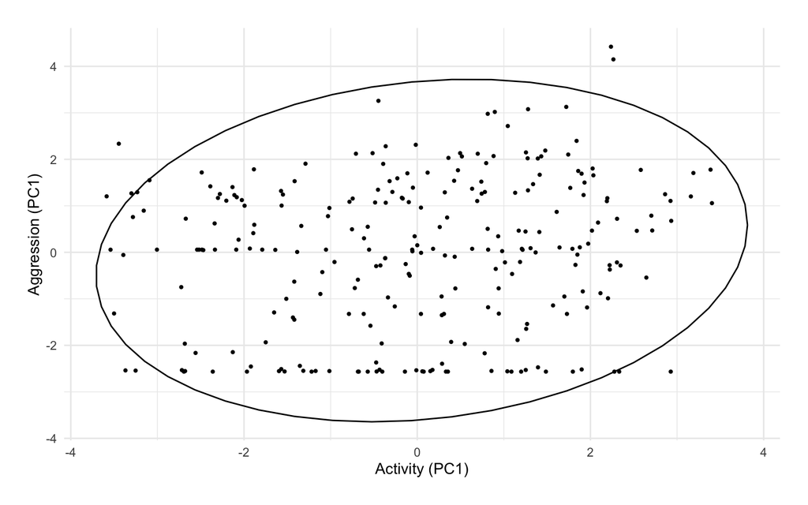

```r
ggplot(personality, aes(oft1, mis1)) +
  geom_point(size = 0.75) +
  stat_ellipse(level = 0.95) +
  labs(x = "Activity (PC1)",
       y = "Aggression (PC1)") +
  theme_minimal() +
  theme(plot.margin = margin(20,20,20,20))
```

We scale spring grid density (may also be referred to as “density” hereafter) and age at time of trial globally, and activity (*oft1*) and aggression (*mis1*) by grid-year combination.

```r
personality <- personality %>%
  mutate(grid_density = scale(grid_density, scale = T, center = T)[,1],
         age_sc = scale(age_at_trial, scale = T, center = T)[,1]) %>%
  group_by(grid, year) %>%
  mutate(oft1 = scale(oft1, scale = T, center = T)[,1],
         mis1 = scale(mis1, scale = T, center = T)[,1]) %>%
  ungroup() %>%
  mutate(treatment = factor(treatment))
```

# Generalized mixed-effects models

## Survival to autumn

Here’s the model for survival to autumn. Fixed effects include:

- Personality measures
  - Activity (*oft1*)
  - Aggression (*mis1*)
  - Interaction between *oft1* and *mis1*
- Part date (*part_sc*)
  - Previously shown to influence juvenile survival (Williams et al., 2014)
- Growth rate (*growth_sc*)
  - Previously shown to be an important predictor of juvenile survival (Fisher et al., 2017; McAdam et al., 2019; Dantzer et al., 2020; Westrick et al., 2021)
- Mast/non-mast year (*mastyear*)
  - Juvenile survival is higher in mast years (McAdam et al., 2003; McAdam et al., 2019)
- Treatment (*treatment*)
- Spring grid density (*grid_density*)
  - Interactions between *grid_density* and
    - *oft1*
    - *mis1*
    - *oft1* x *mis1*
    - *part_sc*
    - *growth_sc*
  - Rationale for the selected interactions with *grid_density* are as below:

    | Variable | Reason |
    | --- | --- |
    | *oft1* | Examine whether selection on activity is density-dependent. |
    | *mis1* | Examine whether selection on aggression is density-dependent. |
    | *oft1* x *mis1* | Examine whether selection on the interaction between activity and aggression is density-dependent. |
    | *part_sc* | Examine whether the effects of parturition date on survival are density-dependent |
    | *growth_sc* | Prior studies have shown that selection on growth rate is density dependent (Dantzer et al., 2013) |

Random effects include:

- Year (of birth) (*year*)
- Litter ID (*litter_id*)

```r
dat = personality %>%
  mutate(across(c(year, dam_id, litter_id, grid, mastyear), as_factor))

survival_to_autumn = glmer(made_it ~
                             oft1*mis1*grid_density +
                             part_sc*grid_density +
                             growth_sc*grid_density +
                             mastyear +
                             treatment +
                             (1|year) +
                             (1|litter_id),
                           data = dat,
                           na.action = 'na.omit',
                           family = binomial(link = "logit"),
                           control = glmerControl(optimizer = "bobyqa", optCtrl = list(maxfun = 1e8)))
```

### ANOVA

```r
car::Anova(survival_to_autumn)
```

```
## Analysis of Deviance Table (Type II Wald chisquare tests)
##
## Response: made_it
##                         Chisq Df Pr(>Chisq)
## oft1                   1.5742  1   0.209604
## mis1                   1.9949  1   0.157826
## grid_density           0.5989  1   0.439005
## part_sc                1.6904  1   0.193549
## growth_sc              0.1780  1   0.673128
## mastyear               7.4313  1   0.006410 **
## treatment              0.1231  1   0.725690
## oft1:mis1              3.1862  1   0.074264 .
## oft1:grid_density      0.4285  1   0.512713
## mis1:grid_density      1.7965  1   0.180138
## grid_density:part_sc   1.1145  1   0.291105
## grid_density:growth_sc 7.0645  1   0.007863 **
## oft1:mis1:grid_density 2.7259  1   0.098731 .
## ---
## Signif. codes:  0 '***' 0.001 '**' 0.01 '*' 0.05 '.' 0.1 ' ' 1
```

- Significant effect of mast year
- Significant interaction between growth rate and spring grid density
- Near-significant interaction between activity and aggression
- Near-significant interactions between activity, aggression, and spring grid density

### Model effects

```r
summary(survival_to_autumn)
```

```
## Generalized linear mixed model fit by maximum likelihood (Laplace
##   Approximation) [glmerMod]
##  Family: binomial  ( logit )
## Formula: made_it ~ oft1 * mis1 * grid_density + part_sc * grid_density +
##     growth_sc * grid_density + mastyear + treatment + (1 | year) +
##     (1 | litter_id)
##    Data: dat
## Control: glmerControl(optimizer = "bobyqa", optCtrl = list(maxfun = 1e+08))
##
##      AIC      BIC   logLik deviance df.resid
##    249.0    303.5   -108.5    217.0      206
##
## Scaled residuals:
##     Min      1Q  Median      3Q     Max
## -5.3559 -0.6145  0.0641  0.6184  2.0894
##
## Random effects:
##  Groups    Name        Variance Std.Dev.
##  litter_id (Intercept) 0.7352   0.8574
##  year      (Intercept) 0.2847   0.5336
## Number of obs: 222, groups:  litter_id, 135; year, 7
##
## Fixed effects:
##                        Estimate Std. Error z value Pr(>|z|)
## (Intercept)             4.03232    1.37904   2.924  0.00346 **
## oft1                    0.06403    0.23868   0.268  0.78848
## mis1                   -0.65618    0.26921  -2.437  0.01479 *
## grid_density           -0.46071    0.38576  -1.194  0.23235
## part_sc                 0.21325    0.24539   0.869  0.38483
## growth_sc               0.22326    0.24979   0.894  0.37142
## mastyearNo             -3.89309    1.42811  -2.726  0.00641 **
## treatmentrattle        -0.23959    0.68286  -0.351  0.72569
## oft1:mis1               0.71819    0.29585   2.428  0.01520 *
## oft1:grid_density       0.29836    0.26907   1.109  0.26749
## mis1:grid_density       0.48910    0.28408   1.722  0.08512 .
## grid_density:part_sc    0.30783    0.29159   1.056  0.29111
## grid_density:growth_sc -0.76678    0.28849  -2.658  0.00786 **
## oft1:mis1:grid_density -0.53036    0.32123  -1.651  0.09873 .
## ---
## Signif. codes:  0 '***' 0.001 '**' 0.01 '*' 0.05 '.' 0.1 ' ' 1
```

```
##
## Correlation matrix not shown by default, as p = 14 > 12.
## Use print(x, correlation=TRUE)  or
##     vcov(x)        if you need it
```

Here, we see that:

- Juvs have better survival during mast years
- More active and aggressive juvs survive better
- Slower growing juvs survive better under high density conditions
- There is a near-significant interaction effect between aggression and conspecific density (more aggressive juvs do better under high density conditions)

### 95% CI

```r
confint(survival_to_autumn,
        method = "Wald")
```

```
##                              2.5 %      97.5 %
## .sig01                          NA          NA
## .sig02                          NA          NA
## (Intercept)             1.32944924  6.73519495
## oft1                   -0.40376947  0.53183904
## mis1                   -1.18382211 -0.12854248
## grid_density           -1.21678020  0.29535284
## part_sc                -0.26769905  0.69419874
## growth_sc              -0.26631242  0.71284056
## mastyearNo             -6.69212904 -1.09404296
## treatmentrattle        -1.57797476  1.09879200
## oft1:mis1               0.13832976  1.29804149
## oft1:grid_density      -0.22901184  0.82574060
## mis1:grid_density      -0.06768495  1.04588909
## grid_density:part_sc   -0.26367163  0.87932820
## grid_density:growth_sc -1.33220608 -0.20135015
## oft1:mis1:grid_density -1.15996254  0.09923737
```

### Model diagnostics

Checking for any collinearity between predictors, where VIF > 3 indicates collinearity:

```r
vif(survival_to_autumn)
```

```
##                   oft1                   mis1           grid_density
##               1.435698               1.732569               1.252845
##                part_sc              growth_sc               mastyear
##               1.271640               1.431757               1.295411
##              treatment              oft1:mis1      oft1:grid_density
##               1.048057               1.926195               1.521509
##      mis1:grid_density   grid_density:part_sc grid_density:growth_sc
##               1.669874               1.277474               1.424022
## oft1:mis1:grid_density
##               1.854179
```

All good here.

```r
simulationOutput = simulateResiduals(survival_to_autumn, plot = F)
residuals(simulationOutput, quantileFunction = qnorm)
```

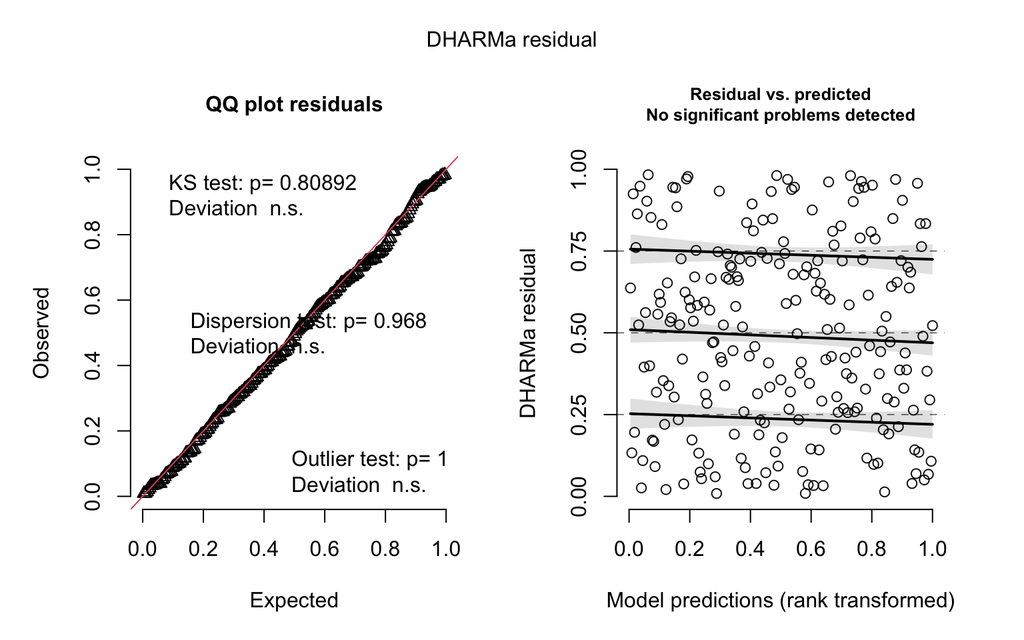

```r
plot(simulationOutput)
```

No deviations here.

## Overwinter survival (200 days)

Here’s the model for overwinter survival. All the fixed effects and random effects are the same as that of the survival to autumn model, except with *survived_to_200d* as the response variable instead.

```r
dat2 = personality %>%
  mutate(across(c(year, dam_id, litter_id, grid, mastyear), as_factor))

survival_to_200d = glmer(survived_200d ~
                           oft1*mis1*grid_density +
                           part_sc*grid_density +
                           growth_sc*grid_density +
                           mastyear +
                           treatment +
                           (1|year) +
                           (1|litter_id),
                         data = dat2,
                         na.action = 'na.omit',
                         family = 'binomial',
                         control = glmerControl(optimizer = "bobyqa", optCtrl = list(maxfun = 1e8)))
```

### ANOVA

```r
car::Anova(survival_to_200d)
```

```
## Analysis of Deviance Table (Type II Wald chisquare tests)
##
## Response: survived_200d
##                          Chisq Df Pr(>Chisq)
## oft1                    0.0024  1  0.9608782
## mis1                    1.3655  1  0.2425794
## grid_density            0.1552  1  0.6936037
## part_sc                 0.0264  1  0.8709567
## growth_sc               0.6738  1  0.4117419
## mastyear                7.3283  1  0.0067876 **
## treatment               0.3420  1  0.5586508
## oft1:mis1               3.5389  1  0.0599446 .
## oft1:grid_density      10.8451  1  0.0009906 ***
## mis1:grid_density       0.0301  1  0.8621925
## grid_density:part_sc    0.8088  1  0.3684671
## grid_density:growth_sc  0.0260  1  0.8719300
## oft1:mis1:grid_density  0.7822  1  0.3764737
## ---
## Signif. codes:  0 '***' 0.001 '**' 0.01 '*' 0.05 '.' 0.1 ' ' 1
```

- Significant effect of mast year
- Significant interaction between activity and density
- Near-significant interaction between activity and aggression.

### Model effects

```r
summary(survival_to_200d)
```

```
## Generalized linear mixed model fit by maximum likelihood (Laplace
##   Approximation) [glmerMod]
##  Family: binomial  ( logit )
## Formula: survived_200d ~ oft1 * mis1 * grid_density + part_sc * grid_density +
##     growth_sc * grid_density + mastyear + treatment + (1 | year) +
##     (1 | litter_id)
##    Data: dat2
## Control: glmerControl(optimizer = "bobyqa", optCtrl = list(maxfun = 1e+08))
##
##      AIC      BIC   logLik deviance df.resid
##    242.1    296.5   -105.0    210.1      206
##
## Scaled residuals:
##     Min      1Q  Median      3Q     Max
## -2.4826 -0.5614 -0.3072  0.4278  3.2865
##
## Random effects:
##  Groups    Name        Variance Std.Dev.
##  litter_id (Intercept) 0.1219   0.3492
##  year      (Intercept) 0.5701   0.7550
## Number of obs: 222, groups:  litter_id, 135; year, 7
##
## Fixed effects:
##                        Estimate Std. Error z value Pr(>|z|)
## (Intercept)             1.53036    0.97942   1.563 0.118167
## oft1                   -0.13606    0.20700  -0.657 0.510991
## mis1                   -0.32687    0.19982  -1.636 0.101887
## grid_density           -0.29200    0.37781  -0.773 0.439596
## part_sc                -0.02431    0.19748  -0.123 0.902028
## growth_sc              -0.15029    0.18866  -0.797 0.425660
## mastyearNo             -3.07883    1.13732  -2.707 0.006788 **
## treatmentrattle         0.44695    0.76422   0.585 0.558651
## oft1:mis1               0.39881    0.19887   2.005 0.044921 *
## oft1:grid_density       0.75694    0.22386   3.381 0.000721 ***
## mis1:grid_density       0.08723    0.20328   0.429 0.667829
## grid_density:part_sc    0.18094    0.20119   0.899 0.368467
## grid_density:growth_sc -0.03008    0.18657  -0.161 0.871930
## oft1:mis1:grid_density -0.18134    0.20504  -0.884 0.376474
## ---
## Signif. codes:  0 '***' 0.001 '**' 0.01 '*' 0.05 '.' 0.1 ' ' 1
```

```
##
## Correlation matrix not shown by default, as p = 14 > 12.
## Use print(x, correlation=TRUE)  or
##     vcov(x)        if you need it
```

Here, we see that:

- Juvs have better survival during mast years
- More active and aggressive juvs survive better
- More active juvs survive better under high density conditions

### 95% CI

```r
confint(survival_to_200d,
        method = "Wald")
```

```
##                               2.5 %      97.5 %
## .sig01                           NA          NA
## .sig02                           NA          NA
## (Intercept)            -0.389268704  3.44997942
## oft1                   -0.541766261  0.26964913
## mis1                   -0.718515373  0.06478137
## grid_density           -1.032498546  0.44849604
## part_sc                -0.411373879  0.36275299
## growth_sc              -0.520056659  0.21947090
## mastyearNo             -5.307936913 -0.84972188
## treatmentrattle        -1.050893959  1.94479865
## oft1:mis1               0.009034567  0.78859526
## oft1:grid_density       0.318191952  1.19569148
## mis1:grid_density      -0.311181697  0.48564514
## grid_density:part_sc   -0.213389615  0.57527687
## grid_density:growth_sc -0.395741094  0.33558902
## oft1:mis1:grid_density -0.583218892  0.22053416
```

### Model diagnostics

Checking for any collinearity between predictors, where VIF > 3 indicates collinearity:

```r
vif(survival_to_200d)
```

```
##                   oft1                   mis1           grid_density
##               1.175752               1.240992               1.323427
##                part_sc              growth_sc               mastyear
##               1.094363               1.096826               1.355624
##              treatment              oft1:mis1      oft1:grid_density
##               1.067350               1.172857               1.276290
##      mis1:grid_density   grid_density:part_sc grid_density:growth_sc
##               1.297694               1.083021               1.073207
## oft1:mis1:grid_density
##               1.258949
```

All good here.

```r
simulationOutput = simulateResiduals(survival_to_200d, plot = F)
residuals(simulationOutput, quantileFunction = qnorm)
```

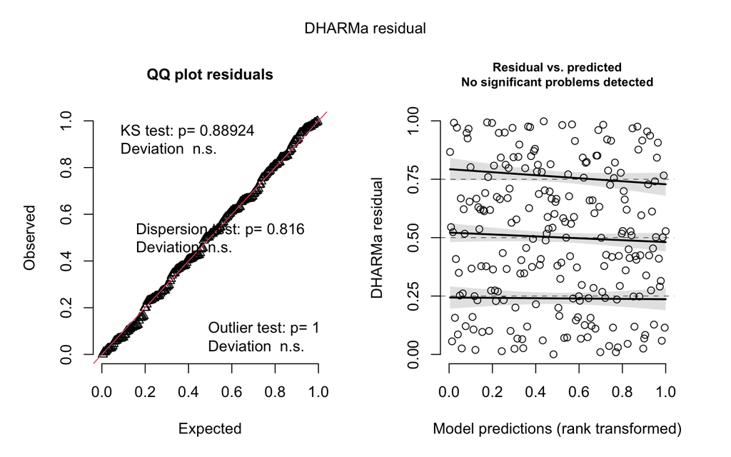

```r
plot(simulationOutput)
```

No deviations here either.